# Conformal Prediction Intervals

2021-04-01

# General useful resources

- https://github.com/valeman/awesome-conformal-prediction
- https://github.com/ryantibs/conformal

There is a [difference](https://robjhyndman.com/hyndsight/intervals/) between prediction and confidence intervals.

# Prediction interval in general

- interval associated with a random variable that will be observed in future and the specific probability of the random variable being situated in this interval

Prediction interval for **new** response:
$$\hat y_h \pm t_{(1-\alpha/2, n-2)} \cdot SE_{pred}$$

$$SE_{pred} = \sqrt{MSE \cdot \left(1+\frac{1}{n}+\frac{(x_h - \bar x)^2}{\sum(x_i - \bar x)^2}\right)}$$

# Confidence interval in general

- frequentist concept concerned with the position of the non-random, but unknown parameter in relation to the interval (“containing the true parameter with some probability, given a large number of repeated samples”)

Confidence interval for **mean** response:

$$\hat y_h \pm t_{(1-\alpha/2, n-2)} \cdot SE_{fit}$$

$$SE_{fit} = \sqrt{MSE \cdot \left(\frac{1}{n}+\frac{(x_h - \bar x)^2}{\sum(x_i - \bar x)^2}\right)}$$

$SE_{fit}$ can approach zero 0 due to missing “extra MSE” term.

# Bayesian credible interval

- interval associated with the posterior distribution of a parameter (parameters are random variables in Bayesian perspective). Similarity to prediction interval, but here the interval is concerned with a parameter value in contrast to the association with an observation when talking about prediction intervals.

# Conformal prediction framework

- [Vovk et al. 2008](https://jmlr.org/papers/v9/shafer08a.html), more thorough treatment in [‘Algorithmic Learning in a Random World’ by Vovk et al. (2005)](https://link.springer.com/book/10.1007/b106715).
- Why? Validity of prediction intervals. The probability of excluding the correct target value is bounded by a predefined confidence level. It makes it possible to assess the uncertainty of each single prediction.

# Regression conformal prediction intervals

- [Johansson et al. 2014](https://link.springer.com/article/10.1007/s10994-014-5453-0)

## Inductive conformal prediction

1. Divide training set into two disjoint sets
   - proper training set $Z^t$
   - calibration set $Z^C$
2. Train the model using proper training set
3. For each calibration instance:
   - predict output
   - calculate non-conformity score $\alpha_i=|y_i - \hat y_i|$
4. Calculate the prediction region:

$$\hat Y_j^{\delta} = \hat y_j \pm \alpha_{s(\delta)}$$

with the smallest $\alpha_{s(\delta)} \in S$ satisfying the equation

$$\frac{\#\{z_i \in Z^C | \alpha_i < \alpha_{s(\delta)}+1 \}}{|Z^C|+1} \geq 1-\delta$$

Let’s generate some data based on the Friedman-problem from the `mlbench`-package and explore the data in a principled way.

```r
library(tidyverse)
library(reshape2)


dat_frame  <- mlbench::mlbench.friedman1(n = 1000, sd = 1)
dat_x  <- dat_frame$x %>%
    as_tibble()
dat_y <- dat_frame$y %>%
    as_tibble()

# independent variables
summary(dat_x)
```

```
       V1                  V2                 V3
 Min.   :0.0009113   Min.   :0.002457   Min.   :0.0000658
 1st Qu.:0.2582361   1st Qu.:0.258183   1st Qu.:0.2471938
 Median :0.4827089   Median :0.511861   Median :0.4982285
 Mean   :0.4980496   Mean   :0.519571   Mean   :0.5013550
 3rd Qu.:0.7507704   3rd Qu.:0.783873   3rd Qu.:0.7600638
 Max.   :0.9995853   Max.   :0.999500   Max.   :0.9998761
       V4                  V5                  V6
 Min.   :0.0009348   Min.   :0.0007637   Min.   :0.001641
 1st Qu.:0.2772354   1st Qu.:0.2415310   1st Qu.:0.264998
 Median :0.5187062   Median :0.5063352   Median :0.525394
 Mean   :0.5146082   Mean   :0.5030531   Mean   :0.515092
 3rd Qu.:0.7689725   3rd Qu.:0.7545317   3rd Qu.:0.768545
 Max.   :0.9966274   Max.   :0.9996321   Max.   :0.999652
       V7                  V8                 V9
 Min.   :0.0004459   Min.   :0.001455   Min.   :0.001251
 1st Qu.:0.2742863   1st Qu.:0.268714   1st Qu.:0.249653
 Median :0.5119216   Median :0.518796   Median :0.494329
 Mean   :0.5157172   Mean   :0.518732   Mean   :0.496284
 3rd Qu.:0.7658872   3rd Qu.:0.772842   3rd Qu.:0.744795
 Max.   :0.9999985   Max.   :0.999585   Max.   :0.999801
      V10
 Min.   :0.0003319
 1st Qu.:0.2552018
 Median :0.4918009
 Mean   :0.4964993
 3rd Qu.:0.7566399
 Max.   :0.9985762
```

```r
# dependent variable
summary(dat_y)
```

```
     value
 Min.   : 0.8769
 1st Qu.:11.0895
 Median :14.7178
 Mean   :14.6067
 3rd Qu.:18.2053
 Max.   :27.6840
```

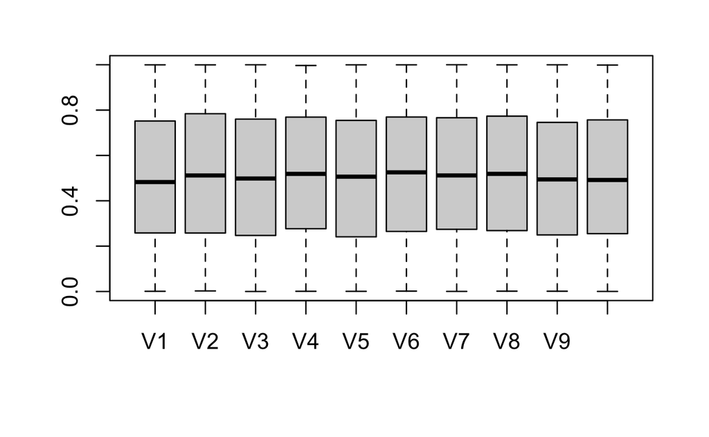

```r
# boxplots
boxplot(dat_x)
```

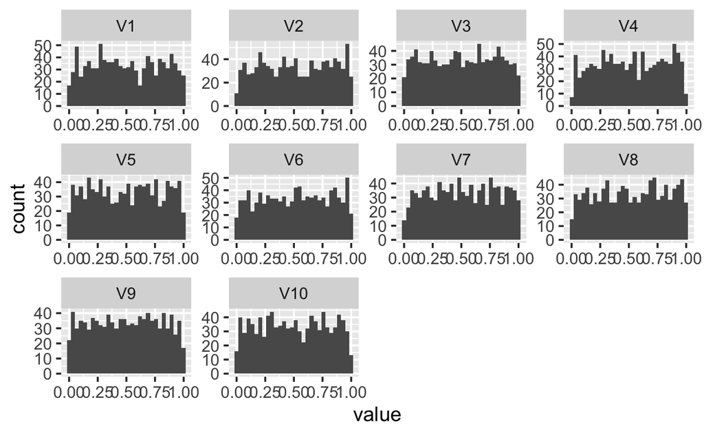

```r
# density plots of vars

#Convert wide to long
melt.x <- reshape2::melt(dat_x)
# plot densities
ggplot(data = melt.x, aes(x = value)) +
    geom_histogram() +
    facet_wrap(~variable, scales = "free")
```